# DAY 4 - Furter regression types

Tamas Nagy

2022-07-13

# Beta regression on proportions

We will use a dataset that contains data from households. We are trying to predict the proportion of spending on food compared to all income by income and number of persons in the household.

```r
# This tutorial is based on Cribari-Neto, F., & Zeileis, A. (2010). Beta Regression in R. Journal of Statistical Software, 34, 1–24. https://doi.org/10.18637/jss.v034.i02

data("FoodExpenditure", package = "betareg")
# Codebook:
# ?FoodExpenditure

# Some data cleaning
food <-
  FoodExpenditure %>%
  as_tibble() %>%
  mutate(food_prop = food/income)

food
```

```
## # A tibble: 38 × 4
##     food income persons food_prop
##    <dbl>  <dbl>   <int>     <dbl>
##  1 16.0    62.5       1     0.256
##  2 16.7    82.3       5     0.202
##  3 21.7    74.7       3     0.291
##  4  7.43   39.2       3     0.190
##  5 10.5    64.7       5     0.162
##  6 13.5    36.8       3     0.368
##  7 23.3    83.1       4     0.280
##  8 18.0    86.9       1     0.207
##  9 14.2    88.2       2     0.160
## 10  8.82   38.7       2     0.228
## # … with 28 more rows
```

We build two beta regressions. In the first, the predictor will be the income, in the other, we also add the number of people in the household.

```r
fe_beta1 <- betareg(food_prop ~ income,
                     data = food)

fe_beta2 <- betareg(food_prop ~ income + persons,
                     data = food)

summary(fe_beta1)
```

```
##
## Call:
## betareg(formula = food_prop ~ income, data = food)
##
## Standardized weighted residuals 2:
##     Min      1Q  Median      3Q     Max
## -2.3052 -0.6693  0.0507  0.5441  2.0583
##
## Coefficients (mean model with logit link):
##              Estimate Std. Error z value Pr(>|z|)
## (Intercept) -0.210329   0.204443  -1.029 0.303578
## income      -0.011879   0.003411  -3.483 0.000496 ***
##
## Phi coefficients (precision model with identity link):
##       Estimate Std. Error z value Pr(>|z|)
## (phi)   27.497      6.218   4.422 9.77e-06 ***
## ---
## Signif. codes:  0 '***' 0.001 '**' 0.01 '*' 0.05 '.' 0.1 ' ' 1
##
## Type of estimator: ML (maximum likelihood)
## Log-likelihood: 40.51 on 3 Df
## Pseudo R-squared: 0.2376
## Number of iterations: 37 (BFGS) + 2 (Fisher scoring)
```

## Interpreting the results

The coefficient can be interpreted as log of proportions that. After exponential transformation, the coefficients correspond to “Proportion Ratio”. For e.g. 50% food ratio means that the other 50% is spent on something else. Thus the ratio is 0.5/0.5 = 1. A value of .99 means that one unit change in the predictor will result in a 1% decrease in the outcome. The value of 1.13 for people means that increase of one person in the household will increase the food proportion by 13%.

```r
tab_model(fe_beta1, fe_beta2,
          show.aic = TRUE,
          show.loglik = TRUE)
```

|  | food prop |  |  | food prop |  |  |
| --- | --- | --- | --- | --- | --- | --- |
| Predictors | Estimates | CI | p | Estimates | CI | p |
| (Intercept) | 0.81 | 0.54 – 1.21 | 0.304 | 0.54 | 0.35 – 0.83 | **0.005** |
| income | 0.99 | 0.98 – 0.99 | **<0.001** | 0.99 | 0.98 – 0.99 | **<0.001** |
| persons |  |  |  | 1.13 | 1.05 – 1.21 | **0.001** |
| Observations | 38 |  |  | 38 |  |  |
| R<sup>2</sup> | 0.238 |  |  | 0.388 |  |  |
| AIC | -75.021 |  |  | -82.667 |  |  |
| log-Likelihood | 40.511 |  |  | 45.334 |  |  |

## The difference from linear regression results

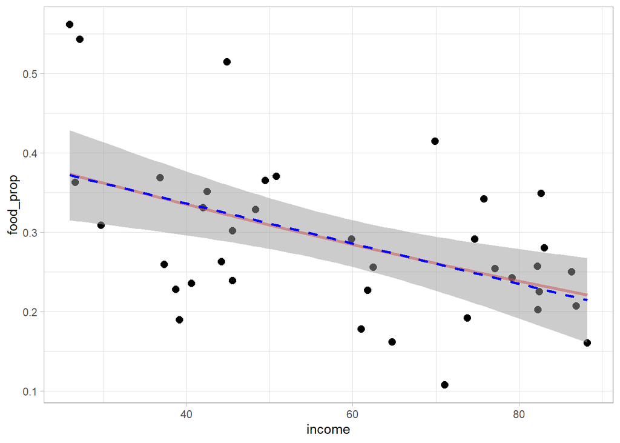

```r
food %>%
  # Add betareg predictions to the dataset
  mutate(pred = predict(fe_beta1, .)) %>%
  ggplot() +
  aes(x = income, y = food_prop) +
  geom_point(size = 2.5) +
  geom_line(aes(y = pred), color = "red", alpha = .5, size = 1.2) +
  # Add a linear regression line for comparison
  geom_smooth(method = lm, color = "blue", alpha = .5, lty = "dashed")
```

When the values are between mostly 0.2 and 0.8, the model is almost exactly the same as a linear regression! So the beta regression is only needed when the data is more dispersed.

# Survival analysis on Game of Thrones data

Analysis question: Is there a smaller chance of survival in Game of Thrones after marriage?

We are building a Cox proportional hazards regression on got character data with the outcome variable that shows if the character is alive or not at particular ages.

```r
# Read GoT character data
got_raw <- read_csv(here("data/got_characters.csv"))
# Make a few transformations to prepare data for survival analysis
got <-
  got_raw %>%
  drop_na(is_alive) %>%
  mutate(death_year = if_else(is_alive == TRUE & birth_year >= 200, 301, death_year),
         status = if_else(is_alive == TRUE, 0, 1),
         age = death_year - birth_year) %>%
  drop_na(death_year)
```

## Fit a standard model without predictors

We fit a survival model with no predictors (only time), and create the KM plot. Median age of dying can be calculated using the `surv_median()` function.

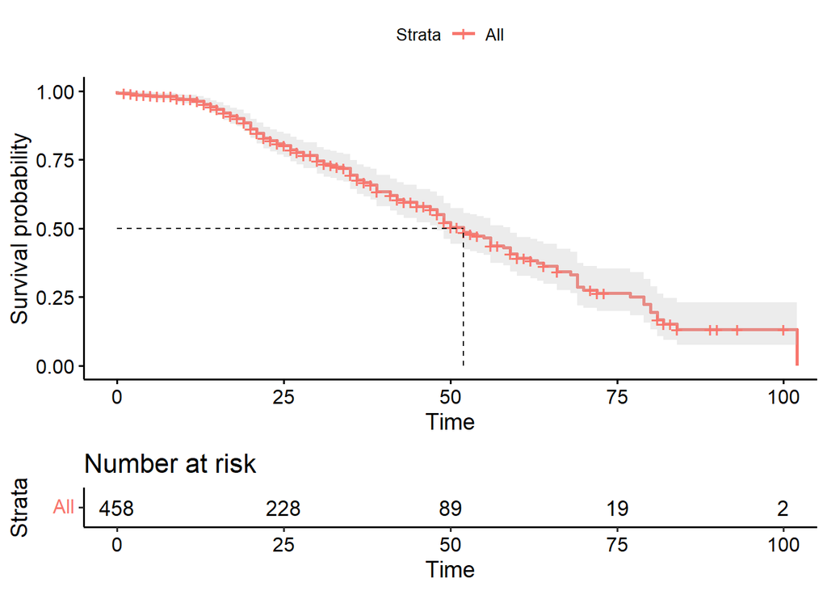

```r
survival_all <- survfit(Surv(age, status) ~ 1, data = got)

ggsurvplot(survival_all,
           surv.median.line = "hv",
           conf.int = TRUE,
           risk.table = TRUE)
```

```r
surv_median(survival_all)
```

```
##   strata median lower upper
## 1    All     52    48    59
```

## Check if gender and spouse predict different mortality

We are looking for main effects of marital status (if the character has a spouse) and gender. We build three models, one with spouse, one with gender, and one with both. The lowest AIC value is for the spouse model, so we don’t include gender in the final model.

```r
survival_model1 <- coxph(Surv(age, status) ~ has_spouse, data = got)
survival_model2 <- coxph(Surv(age, status) ~ has_spouse + gender, data = got)
survival_model3 <- coxph(Surv(age, status) ~ gender, data = got)

AIC(survival_model1, survival_model2, survival_model3)
```

```
##                 df      AIC
## survival_model1  1 1705.996
## survival_model2  2 1707.985
## survival_model3  1 1710.252
```

## Evaluate the model

We will check model summary, and the effect of having married. We can check if there are differences between the groups using the `surv_pvalue()` function.

```r
# Model summary
summary(survival_model1)
```

```
## Call:
## coxph(formula = Surv(age, status) ~ has_spouse, data = got)
##
##   n= 458, number of events= 172
##    (331 observations deleted due to missingness)
##
##                  coef exp(coef) se(coef)     z Pr(>|z|)
## has_spouseTRUE 0.3285    1.3888   0.1544 2.127   0.0334 *
## ---
## Signif. codes:  0 '***' 0.001 '**' 0.01 '*' 0.05 '.' 0.1 ' ' 1
##
##                exp(coef) exp(-coef) lower .95 upper .95
## has_spouseTRUE     1.389       0.72     1.026      1.88
##
## Concordance= 0.489  (se = 0.021 )
## Likelihood ratio test= 4.52  on 1 df,   p=0.03
## Wald test            = 4.52  on 1 df,   p=0.03
## Score (logrank) test = 4.56  on 1 df,   p=0.03
```

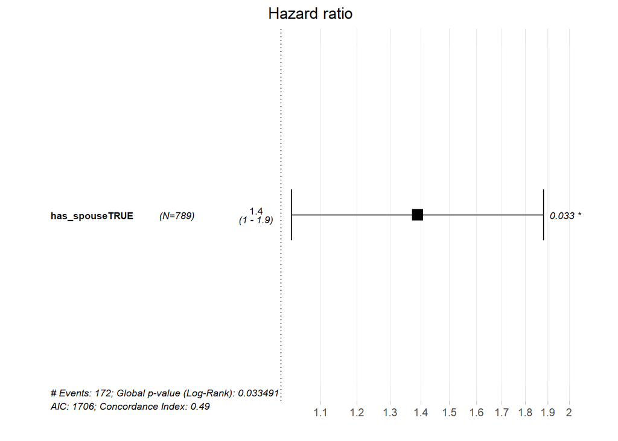

```r
# We can make a forest plot of effects
ggforest(survival_model1, data = got)
```

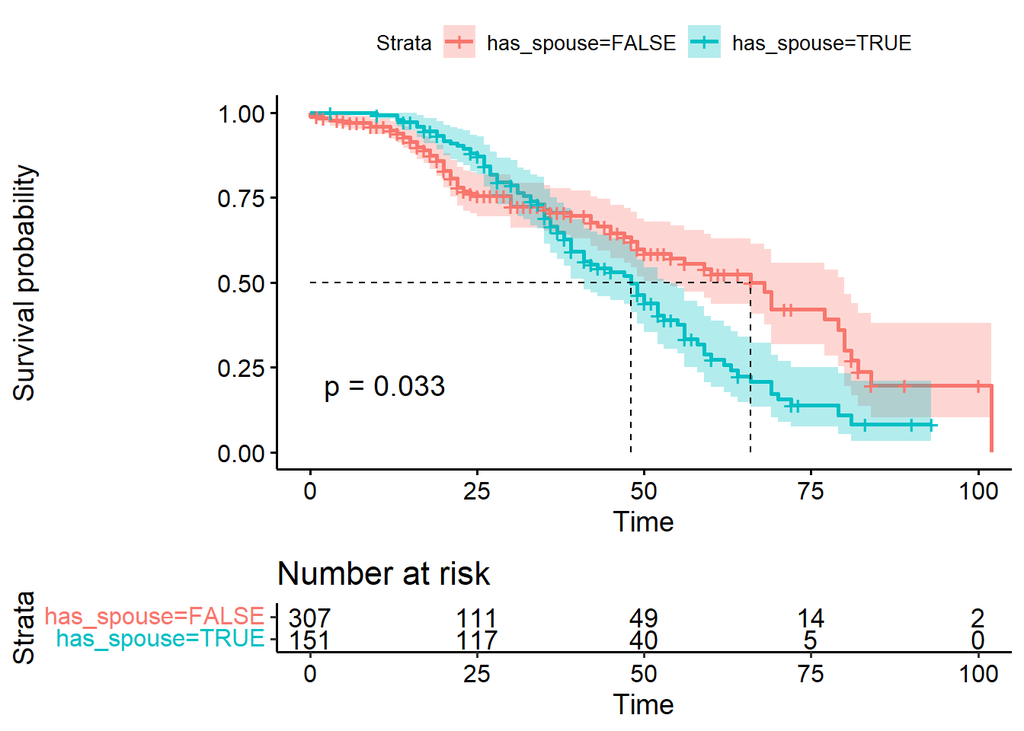

```r
# Refit the model for visualization and further calculations
survival_model1 <- survfit(Surv(age, status) ~ has_spouse, data = got)

# Plot the two groups
ggsurvplot(survival_model1,
           surv.median.line = "hv",
           conf.int = TRUE,
           pval = TRUE,
           risk.table = TRUE)
```

```r
surv_median(survival_model1)
```

```
##             strata median lower upper
## 1 has_spouse=FALSE     66    54    80
## 2  has_spouse=TRUE     48    41    53
```

```r
surv_pvalue(survival_model1)
```

```
##     variable       pval   method  pval.txt
## 1 has_spouse 0.03346369 Log-rank p = 0.033
```